# Análise de Dados do ENEM

Lucas Lopes

01/03/2022

## Objetivo

O Exame Nacional do Ensino Médio (Enem) foi instituído em 1998, com o objetivo de avaliar o desempenho escolar dos estudantes ao término da educação básica. Em 2009, o exame aperfeiçoou sua metodologia e passou a ser utilizado como mecanismo de acesso à educação superior. Esta análise tem por objetivo fornecer insigths sobre os os microdados do enem bem como sobre os participantes e os estados brasileiros.

### Pergunta 1 - Quais dados (arquivos) utilizados, onde e como foram obtidos?

### Dados utilizados nesta análise

Microdados do [ENEM](https://www.gov.br/inep/pt-br/acesso-a-informacao/dados-abertos/microdados/enem) edições 2017, 2018 e 2019 e dados do Censo Escolar disponibilizados pelo INEP.

[figure not shown]

Dados de coordenadas das estruturas geográficas do Brasil obtidos da plataforma [GeoJs](https://geojson.org/).

[figure not shown]

Importando as bibliotecas para análise de dados

```r
options(warn=-1)
library(readr)
library(dplyr)
library(ggplot2)
library(data.table)
library(tidyverse)
library(sf)
library(tidyr, include.only = 'replace_na')
library(reshape2, include.only = 'melt')
library(stringr, include.only = 'str_replace')
library(rjson, include.only = 'fromJSON')
```

Os arquivos com os microdados do ENEM possuem cerca de 3 a 4 GB de tamanho, o que torna sua manipulação complexa em termos de tempo de processamento. Para contornar esta limitação, foram carregadas somente as colunas com as quais iremos trabalhar e apenas as primeiras 100 mil linhas de cada tabela, reduzindo, assim, o tempo de processamento. No [repositório Análise de Dados do ENEM com Python](https://github.com/luflopes/Analise_Dados_Enem_2017_ate_2019_Python) é possível encontrar a análise dos conjuntos de dados inteiros.

Importando o arquivo MICRODADOS_ENEM_2017.csv

```r
dados_enem_2017 <- fread(file='./DADOS/MICRODADOS_ENEM_2017.csv', nrows=100000,
                    sep=';',
                    select=c('NU_INSCRICAO', 'NU_ANO','NO_MUNICIPIO_RESIDENCIA',
                          'NO_MUNICIPIO_NASCIMENTO', 'SG_UF_NASCIMENTO',
                          'NO_MUNICIPIO_ESC', 'CO_ESCOLA','SG_UF_ESC',
                          'NU_NOTA_CN', 'NU_NOTA_CH', 'NU_NOTA_LC',
                          'NU_NOTA_MT','NU_NOTA_REDACAO', 'Q006'))
```

Importando o arquivo MICRODADOS_ENEM_2018.csv

```r
dados_enem_2018 <- fread(file='./DADOS/MICRODADOS_ENEM_2018.csv', nrows=100000,
                    sep=';',
                    select=c('NU_INSCRICAO', 'NU_ANO','NO_MUNICIPIO_RESIDENCIA',
                          'NO_MUNICIPIO_NASCIMENTO', 'SG_UF_NASCIMENTO',
                          'NO_MUNICIPIO_ESC', 'CO_ESCOLA','SG_UF_ESC',
                          'NU_NOTA_CN', 'NU_NOTA_CH', 'NU_NOTA_LC',
                          'NU_NOTA_MT','NU_NOTA_REDACAO', 'Q006'))
```

Importando o arquivo MICRODADOS_ENEM_2019.csv

```r
dados_enem_2019 <- fread(file='./DADOS/MICRODADOS_ENEM_2019.csv', nrows=100000,
                    sep=';',
                    select=c('NU_INSCRICAO', 'NU_ANO','NO_MUNICIPIO_RESIDENCIA',
                          'NO_MUNICIPIO_NASCIMENTO', 'SG_UF_NASCIMENTO',
                          'NO_MUNICIPIO_ESC', 'CO_ESCOLA','SG_UF_ESC',
                          'NU_NOTA_CN', 'NU_NOTA_CH', 'NU_NOTA_LC',
                          'NU_NOTA_MT','NU_NOTA_REDACAO', 'Q006'))
```

Concatenando as tabelas das edições 2017, 2018 e 2019 em apenas uma tabela

```r
dados_enem_2017_to_2019 <- rbind(dados_enem_2017, dados_enem_2018, dados_enem_2019)
```

Removendo os dataframes carregados da memória para reduzir a utilização de memória RAM

```r
rm(dados_enem_2018, dados_enem_2018, dados_enem_2019)
```

Salvando a tabela gerada pela união dos dados de 2017, 2018 e 2019 em formato csv

```r
write.csv(dados_enem_2017_to_2019,
          file='./DADOS/dados_enem_2017_to_2019.csv',
          sep=';')
```

Importando o arquivo gerado com as edições do ENEM de 2017 até 2019

```r
dados_enem <- fread(file='./DADOS/dados_enem_2017_to_2019.csv')
```

### Pergunta 2 - Qual o tipo de tratamento será aplicado à base de dados?

As técnicas que serão utilizadas no decorrer da análise incluem:

*Remodelagem de dados;* Tratamento de valores missing; *Análise estatística descritiva;* Visualição de dados *Storytelling

### Pergunta 3 - Qual a proporção de missing nas bases e o que será feito com esses casos? Quais os mais relevantes?

Verificando o shape dos dados

```r
dim(dados_enem)
```

```
## [1] 300000     15
```

Verificando os tipos de dados das colunas

```r
str(dados_enem)
```

```
## Classes 'data.table' and 'data.frame':   300000 obs. of  15 variables:
##  $ V1                     : int  1 2 3 4 5 6 7 8 9 10 ...
##  $ NU_INSCRICAO           :integer64 170003336736 170003333545 170001663644 170001663645 170001663646 170001663647 170003334115 170003334116 ...
##  $ NU_ANO                 : int  2017 2017 2017 2017 2017 2017 2017 2017 2017 2017 ...
##  $ NO_MUNICIPIO_RESIDENCIA: chr  "Araraquara" "Cassilândia" "São Paulo" "Lages" ...
##  $ NO_MUNICIPIO_NASCIMENTO: chr  "Araraquara" "Cassilândia" "São Paulo" "Lages" ...
##  $ SG_UF_NASCIMENTO       : chr  "SP" "MS" "SP" "SC" ...
##  $ NO_MUNICIPIO_ESC       : chr  "" "" "" "" ...
##  $ CO_ESCOLA              : int  NA NA NA NA NA NA NA NA NA NA ...
##  $ SG_UF_ESC              : chr  "" "" "" "" ...
##  $ NU_NOTA_CN             : num  445 NA NA 604 482 ...
##  $ NU_NOTA_CH             : num  589 NA NA 610 569 ...
##  $ NU_NOTA_LC             : num  622 NA NA 564 571 ...
##  $ NU_NOTA_MT             : num  466 NA NA 591 585 ...
##  $ NU_NOTA_REDACAO        : int  560 NA NA 580 580 540 400 NA NA 320 ...
##  $ Q006                   : chr  "D" "C" "G" "D" ...
##  - attr(*, ".internal.selfref")=<externalptr>
```

Deletando a coluna de índice gerada durante a junção dos dados

```r
dados_enem <- mutate(dados_enem, V1 = NULL)
```

Adequando os tipos de dados

```r
dados_enem$NU_ANO <- as.factor(dados_enem$NU_ANO)
dados_enem$NU_INSCRICAO <- as.character(dados_enem$NU_INSCRICAO)
```

Visualizando o conjunto de dados

```r
library(rmarkdown)
paged_table(head(dados_enem))
```

| NU_INSCRICAO | NU_ANO | NO_MUNICIPIO_RESIDENCIA | NO_MUNICIPIO_NASCIMENTO | SG_UF_NASCIMENTO | NO_MUNICIPIO_ESC | CO_ESCOLA | SG_UF_ESC | NU_NOTA_CN | NU_NOTA_CH | NU_NOTA_LC | NU_NOTA_MT | NU_NOTA_REDACAO | Q006 |
| --- | --- | --- | --- | --- | --- | --- | --- | --- | --- | --- | --- | --- | --- |
| 170003336736 | 2017 | Araraquara | Araraquara | SP |  | NA |  | 445.4 | 589.0 | 621.5 | 465.5 | 560 | D |
| 170003333545 | 2017 | Cassilândia | Cassilândia | MS |  | NA |  | NA | NA | NA | NA | NA | C |
| 170001663644 | 2017 | São Paulo | São Paulo | SP |  | NA |  | NA | NA | NA | NA | NA | G |
| 170001663645 | 2017 | Lages | Lages | SC |  | NA |  | 604.0 | 610.4 | 563.9 | 591.2 | 580 | D |
| 170001663646 | 2017 | Maceió | Maceió | AL |  | NA |  | 482.1 | 569.2 | 570.8 | 584.6 | 580 | C |
| 170001663647 | 2017 | Cachoeirinha | Porto Alegre | RS |  | NA |  | 558.8 | 594.9 | 522.8 | 578.5 | 540 | J |

Verificando a quantidade de valores NA e sua proporção no total de registros

```r
na_data <- sapply(dados_enem, function(x) sum(is.na(x)))
na_data <- data.frame(na_data)
na_data$colunas <- row.names(na_data)
row.names(na_data) <- c(1:length(na_data$colunas))
paged_table(na_data)
```

|  | na_data | colunas |
| --- | --- | --- |
| 1 | 0 | NU_INSCRICAO |
| 2 | 0 | NU_ANO |
| 3 | 0 | NO_MUNICIPIO_RESIDENCIA |
| 4 | 0 | NO_MUNICIPIO_NASCIMENTO |
| 5 | 0 | SG_UF_NASCIMENTO |
| 6 | 0 | NO_MUNICIPIO_ESC |
| 7 | 239121 | CO_ESCOLA |
| 8 | 0 | SG_UF_ESC |
| 9 | 80707 | NU_NOTA_CN |
| 10 | 69122 | NU_NOTA_CH |

[output cut: 4 more lines]

```r
na_data <- na_data %>%
            filter(na_data > 0) %>%
            mutate(perc_na = round((na_data / sum(na_data))*100, 2))

paged_table(na_data)
```

| na_data | colunas | perc_na |
| --- | --- | --- |
| 239121 | CO_ESCOLA | 39.34 |
| 80707 | NU_NOTA_CN | 13.28 |
| 69122 | NU_NOTA_CH | 11.37 |
| 69122 | NU_NOTA_LC | 11.37 |
| 80707 | NU_NOTA_MT | 13.28 |
| 69122 | NU_NOTA_REDACAO | 11.37 |

Gerando gráfico da porcentagem de valores NA por coluna

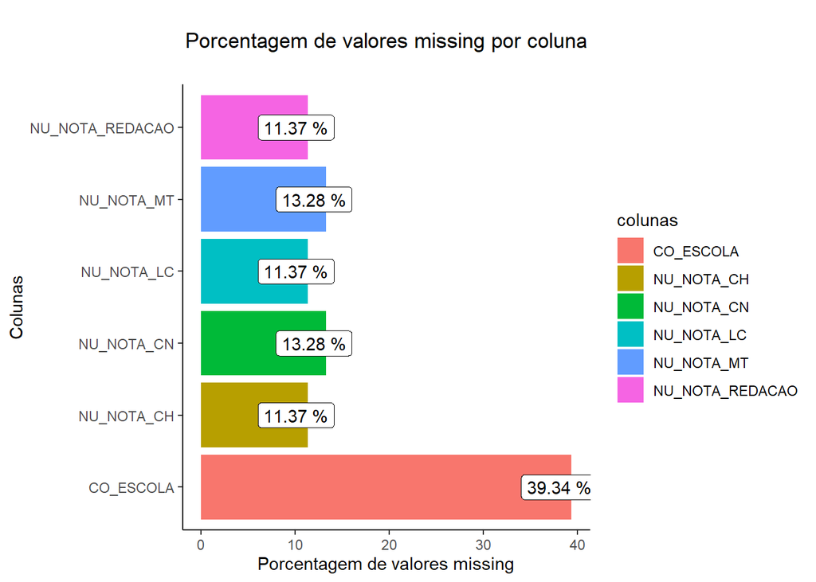

```r
ggplot(na_data, aes(x = perc_na, y = colunas,))+
  geom_col(aes(xmin = 0, xmax=100 , fill = colunas),
           width = 0.9) +
  geom_label(
    label=paste(na_data$perc_na, '%'),
    nudge_x = -1.3, nudge_y = 0) +
labs(
  title = '\n Porcentagem de valores missing por coluna \n',
  y = 'Colunas', x = 'Porcentagem de valores missing') +
  theme_bw() + theme(plot.title = element_text(hjust = 0.5),
                     panel.border = element_blank(),
                       panel.grid.major = element_blank(),
                       panel.grid.minor = element_blank(),
                       axis.line = element_line(colour = "black"))
```

### Tratamento de Valores Missing (Premissas)

*Os valores missing da coluna “CO_ESCOLA” serão excluídos uma vez que não é possível fazer uma predição 100% certa sobre cógigo da escola (variável categórica)

*As colunas que representam as notas terão os valores missing substituídos por 0 (Zero), assumindo que os participantes desistiram de realizar a prova. Neste caso, também poderíamos substituir pela mediana dos dados, mas correríamos o risco de comprometer a veracidade da informação de quantos alunos desistiram de realizar a prova.

Removendo os dados missing da coluna “CO_ESCOLA”

```r
dados_enem <- dados_enem %>%
            filter(CO_ESCOLA != is.na(CO_ESCOLA))
```

Substituindo os valores missing da coluna “NO_MUNICIPIO_ESC” pelos valores da coluna “NO_MUNICIPIO_NASCIMENTO”

```r
vetor_NO <- list(dados_enem$NO_MUNICIPIO_ESC,dados_enem$NO_MUNICIPIO_NASCIMENTO)
vetor_NO <- coalesce(!!!vetor_NO)
sum(is.na(vetor_NO))
dados_enem <- dados_enem %>%
  mutate(NO_MUNICIPIO_ESC = vetor_NO, NO_MUNICIPIO_NASCIMENTO = NULL)

rm(vetor_NO)
```

Substituindo os valores missing da coluna “SG_UF_ESC” pelos valores da coluna “SG_UF_NASCIMENTO” uma vez que não será possível determinar a UF se ele não estiver presente em nenhuma das duas colunas utilizadas.

```r
vetor_SG <- list(dados_enem$SG_UF_ESC,dados_enem$SG_UF_NASCIMENTO)
vetor_SG <- coalesce(!!!vetor_SG)
sum(is.na(vetor_SG))
dados_enem <- dados_enem %>%
  mutate(SG_UF_ESC = vetor_SG, SG_UF_NASCIMENTO = NULL)

rm(vetor_SG)
```

Substituindo os valores missing das colunas de nota por 0 (Zero). Aqui entendemos que os valores NA representam participantes que não foram realizar a prova.

```r
dados_enem <- dados_enem %>%
    mutate(NU_NOTA_CN = replace_na(NU_NOTA_CN, 0),
           NU_NOTA_CH = replace_na(NU_NOTA_CH, 0),
           NU_NOTA_LC = replace_na(NU_NOTA_LC, 0),
           NU_NOTA_MT = replace_na(NU_NOTA_MT, 0),
           NU_NOTA_REDACAO = replace_na(NU_NOTA_REDACAO, 0))
```

Verificando a quantidade de valores missing após o tratamento dos dados

```r
gc(reset = TRUE)
```

```
##            used  (Mb) gc trigger  (Mb) max used  (Mb)
## Ncells  1775957  94.9    2873981 153.5  1775957  94.9
## Vcells 23680223 180.7   66034683 503.9 23680223 180.7
```

```r
na_data2 <- sapply(dados_enem, function(x) sum(is.na(x)))
na_data2 <- data.frame(na_data2)
paged_table(na_data2)
```

[output not shown]

[output cut: 4 more lines]

### Pergunta 4 - Qual o número de inscritos por ano? Existe alguma tendência a ser observada nos dados?

Plotando o gráfico com a quantidade de inscritos por ano

```r
qtd_insc_ano <-  dados_enem %>%
  select(NU_ANO, NU_INSCRICAO) %>%
  group_by(NU_ANO) %>%
  summarise(contagem = n())

colnames(qtd_insc_ano) <- c('Ano', 'Quantidade')
```

Plotando o gráfico com a quantidade de inscritos por ano

[figure not shown]

```r
ggplot(qtd_insc_ano, aes(x = as.factor(Ano), y=Quantidade)) +
  geom_col(aes(ymin=0, ymax=max(qtd_insc_ano$Quantidade), fill=as.factor(Ano))) +
  geom_label( aes(y=qtd_insc_ano$Quantidade),
    label= qtd_insc_ano$Quantidade,
    nudge_x = 0, nudge_y = 1,
    check_overlap = T) +
  labs(
    title = '\n Quantidade de inscrições no ENEM por ano \n',
    y = 'Quantidade', x = 'Ano') +
  theme_bw() + theme(plot.title = element_text(hjust = 0.5),
                     panel.border = element_blank(),
                     panel.grid.major = element_blank(),
                     panel.grid.minor = element_blank(),
                     axis.line = element_line(colour = "black"))
```

### Pergunta 5 - Quais as notas médias por ano de realização da prova?

Remodelagem do conjunto de dados para possibilitar a análise de forma gráfica

```r
dados_enem <- melt(dados_enem,
                    id.vars = c("NU_INSCRICAO", "NU_ANO",
                                "NO_MUNICIPIO_RESIDENCIA", "NO_MUNICIPIO_ESC",
                                "CO_ESCOLA", "SG_UF_ESC",
                                "Q006"),
                    variable.name = "AREA_CON",
                    value.name = "NOTA")
paged_table(head(dados_enem))
```

[output not shown]

Verificando a quantidade de linhas e colunas da nova tabela

```r
dim(dados_enem)
```

[output not shown]

Remodelando os dados da coluna AREA_CONHECIMENTO

```r
dados_enem$AREA_CON <- str_replace(dados_enem$AREA_CON, 'NU_NOTA_CN', 'Ciencias da Natureza' )
dados_enem$AREA_CON <- str_replace(dados_enem$AREA_CON, 'NU_NOTA_CH', 'Ciencias Humanas' )
dados_enem$AREA_CON <- str_replace(dados_enem$AREA_CON, 'NU_NOTA_LC', 'Linguagens e Codigos' )
dados_enem$AREA_CON <- str_replace(dados_enem$AREA_CON, 'NU_NOTA_MT', 'Matematica' )
dados_enem$AREA_CON <- str_replace(dados_enem$AREA_CON, 'NU_NOTA_REDACAO', 'Redação' )
```

Calculando a média por ano e por Área do conhecimento.

```r
notas_ano_area <- dados_enem %>%
                  select(NU_ANO, AREA_CON, NOTA) %>%
                  group_by(NU_ANO, AREA_CON) %>%
                  summarise(media_ano_area = mean(NOTA))
```

Criando o gráfico para visualização da média por ano e por Área do conhecimento.

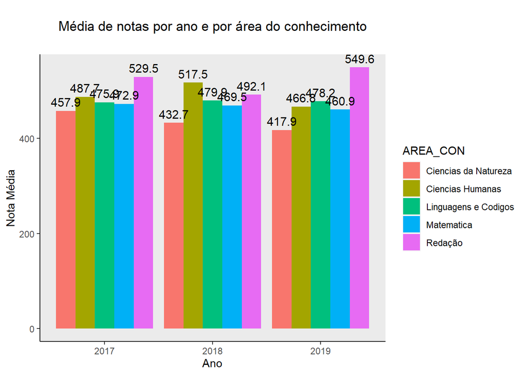

```r
ggplot(notas_ano_area, aes(x = NU_ANO, y=media_ano_area, fill=AREA_CON)) + # (1)

  geom_col(position = 'dodge') + # (2)

  geom_text(aes(label = round(media_ano_area, 1)),
            position = position_dodge(.9),  vjust = -.5, size=4) + # (3)

  labs(title = '\n Média de notas por ano e por área do conhecimento \n',
            y = 'Nota Média', x = 'Ano') + # (4)

  theme(plot.title = element_text(hjust = 0.5),
                     panel.border = element_blank(),
                     panel.grid.major = element_blank(),
                     panel.grid.minor = element_blank(),
                     axis.line = element_line(colour = "black")) # (6)
```

### Pergunta 6 - Qual a renda média dos participantes por estado?

Dados de renda obtidos do dicinário de dados do ENEM. Estes dados indicam a faixa de renda dos participantes do ENEM.

```r
Q006 <- c('A','B','C','D','E','F','G','H','I','J','K','L','M','N','O','P','Q')

RENDA <- c(0, 937.00,1405.50,1874.00,2342.50,2811.00,3748.00,4685.00,5622.00,
           6559.00,7496.00,8433.00,9370.00,11244.00,14055.00,18740.00,18740.00)

# Criando uma tabela temporária

temp <- tibble(Q006, RENDA)

# Mesclando os dados das duas tabelas dados_enem e temp para criar uma
# coluna com os dados de renda na tabela dados_enem

dados_enem <- left_join (dados_enem , temp , by = c ( "Q006" = "Q006"))
```

Calculando a média de notas por estado.

```r
media_estado <- dados_enem %>%
  select(SG_UF_ESC, NOTA, RENDA) %>%
  filter(SG_UF_ESC != "" & RENDA != is.na(NA) ) %>%
  group_by(SG_UF_ESC) %>%
  summarise(nota_media = mean(NOTA), renda_media = mean(RENDA)) %>%
  arrange(SG_UF_ESC)
```

Você pode entrar no link abaixo e baixar os mapas de interesse. Aqui, iremos baixar o arquivo br_unidades_da_federacao.zip. Link: Dados IBGE. Vamos usar a função **st_read()** do pacote **sf** (simple features)

```r
file <- './DADOS/shapes/BRUFE250GC_SIR.shp'

br_uf <- st_read(file, stringsAsFactors = FALSE)

br_uf <- br_uf %>% arrange(NM_ESTADO)
```

Vamos importar um conjunto de de pares de valores (key:value) do arquivo disponibilizado no [GeoJS](https://geojson.org/) com as siglas e nomes dos estados para fazer o link entre os nomes, notas e siglas dos estados.

```r
estados_brasil <- fromJSON(file = "./DADOS/brazil_geo.json")
```

Precisaremos cruzar dados dos 2 arquivos importados acima (.shp e .json) acima. Obtendo o os pares (SIGLA : NOME DO ESTADO)

```r
lista_estados <- list()

for (feature in estados_brasil$features){
  lista_estados[[feature$id]] = feature$properties$name
}
```

Criando uma lista apenas com os nomes dos estados na ordem em que as siglas aparecem na tabela media_estado.

```r
lista_dos_estados <- c()

for (estado in media_estado$SG_UF_ESC){
  lista_dos_estados <-  append(x = lista_dos_estados, values = lista_estados[[estado]])
}
```

Criando uma coluna com os nomes dos estados obtidos acima para a tabela media_estado e fazendo um merge com as tabelas br_uf que contém as geometrias por estados e a tabela media_estado que possui as notas médias por estado

```r
media_estado$NM_ESTADO <- toupper(lista_dos_estados)
media_estado <- left_join (br_uf , media_estado , by = c ( "NM_ESTADO" = "NM_ESTADO"))
```

Tendo todas as informações na tabela media_estado, vamos remover da mémória as variáveis que não usaremos mais.

```r
rm(lista_estados, lista_dos_estados, br_uf, estados_brasil, temp)
```

Agora vamos construir um gráfico de polígonos (mapa) no ggplot2 com a renda média dos participantes estado.

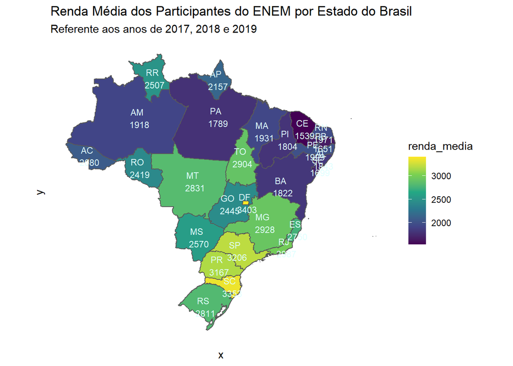

```r
ggplot(data = media_estado, aes(fill = renda_media)) +
  geom_sf() +
  labs(
    title = "Renda Média dos Participantes do ENEM por Estado do Brasil ",
    subtitle = "Referente aos anos de 2017, 2018 e 2019",
    fill = "renda_media"
  ) +
  # A partir de agora são só ajustes do gráfico
  theme(
    legend.position = "right",
    panel.background = element_blank(),
    panel.grid.major = element_line(color = "transparent"),
    axis.text = element_blank(),
    axis.ticks = element_blank()
  )  +
  scale_fill_viridis_c() +
  geom_sf_text(aes(label = paste(SG_UF_ESC,'\n' ,round(renda_media, 0))),
               label.padding = unit(0.5, "mm"), size = 3, colour = "#E0FFFF")
```

### Pergunta 7 - Qual a nota média por estado?

Agora vamos construir um gráfico de polígonos (mapa) no ggplot2 com a nota média por estado.

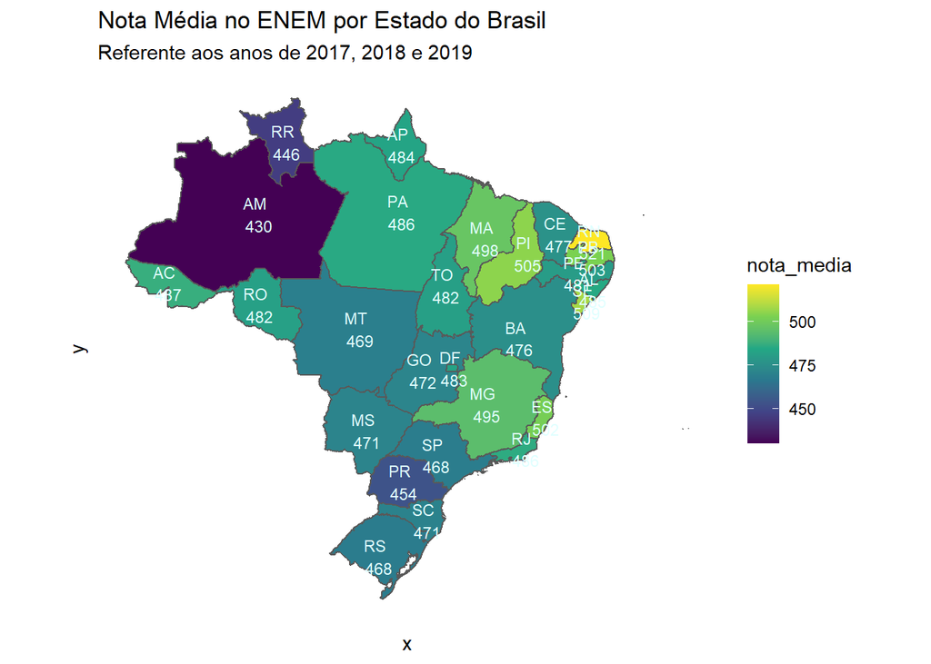

```r
ggplot(data = media_estado, aes(fill = nota_media)) +
  geom_sf() +
  labs(
    title = "Nota Média no ENEM por Estado do Brasil ",
    subtitle = "Referente aos anos de 2017, 2018 e 2019",
    fill = "nota_media"
  ) +
  # A partir de agora são só ajustes do gráfico
  theme(
    legend.position = "right",
    panel.background = element_blank(),
    panel.grid.major = element_line(color = "transparent"),
    axis.text = element_blank(),
    axis.ticks = element_blank()
  )  +
  scale_fill_viridis_c() +
  geom_sf_text(aes(label = paste(SG_UF_ESC,'\n' ,round(nota_media, 0))),
               label.padding = unit(0.5, "mm"), size = 3, colour = "#E0FFFF")
```

Este conjunto de dados oferece muitas possibilidades no âmbito das Análises Exploratórias, sendo assim pretendo continuar este trabalho respondendo a outras questões como: * Existe alguma relação entre a renda média e a nota média por estado? * Existe relação entre a raça dos participantes e seu desempenho nas provas? * Quais as escolas com melhor melhor desempenho em cada ano? * Quais as escolas com melhor o pior desempenho em cada ano?

### Obrigado se você chegou até aqui.